# 외국인 ‘셰이크아웃’ 가설 검증 리포트

이재명 정부 취임 전/후 KOSPI 외국인 매매 행태 비교 분석

작성일 2026-06-06 | 데이터 834거래일 (2023-01-02 ~ 2026-06-05: 취임 전 589일 / 후 245일) | 출처: 네이버 금융 (KRX 집계), raw·백업 교차검증 오차 0

## 1. 검증 가설

**가설:** 취임(2025-06-04) 전에는 “외국인 대량매도 → 지수 하락 → 개인 투매(셰이크아웃) → 외국인 저가 재매수” 사이클이 존재했으나, 취임 후에는 이 패턴이 역전되거나 상관성이 소멸했다.

## 2. 판정 요약

기각 **취임 전 셰이크아웃 사이클 존재**  
완전 시퀀스 13% (5/39건) vs 무작위 기준선 11%, p=0.458 — 우연 수준. **취임 전에도 사이클은 없었다.**

절반만 일치 **취임 후 사이클 소멸/무상관**  
사이클은 원래 없었음(20% vs 11%, p=0.311). 단, 상관성은 소멸이 아니라 **오히려 취임 후 출현**.

실제 발견 **레짐 전환의 실체**  
양방향 트레이딩(중립) → 정보 우위를 동반한 대규모 일방 이탈(분배)로 전환.

## 3. 데이터 개관

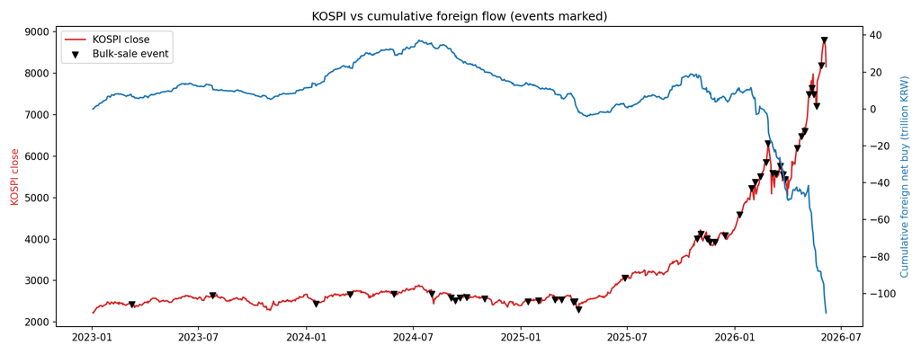

그림 1. KOSPI 종가(적)와 외국인 누적 순매수(청), 대량매도 이벤트(▼). 취임 후 지수 +194.5% 급등과 외국인 -108.8조 순매도가 동시 진행.

| 지표 | 취임 전 (2023-01~2025-06) | 취임 후 (2025-06~2026-06) |
| --- | --- | --- |
| 거래일 수 | 589일 | 245일 |
| KOSPI 범위 | 2,219 ~ 2,891 (박스권) | 2,771 → 8,161 (+194.5%) |
| 외국인 누적 순매수 | -1.8조 원 (사실상 중립) | -108.8조 원 (대규모 이탈) |
| 외국인 일평균 \|순매수\| | 0.32조 원 | 1.06조 원 (3.3배) |
| 수급 주체 | — | 개인 +47.0조 / 기관 +44.7조 매수 |

## 4. 셰이크아웃 시퀀스 검정

4단계 시퀀스를 조작적으로 정의: ① 외인 대량매도(하위 10% 분위) → ② 하락(t~t+2 누적수익률<0) → ③ 개인 투매(t+1~t+5 개인 순매도) → ④ 외인 재매수(t+3~t+15 순매수 전환). 완성률을 부트스트랩 2,000회 무작위 기준선과 비교.

| 단계 | 취임 전 (N=39) | 취임 후 (N=10) |
| --- | --- | --- |
| ② 하락 | 64% | 60% |
| ③ 개인 투매 | 41% | 30% |
| ④ 외인 재매수 | 36% | 30% |
| **완전 시퀀스 (②③④ 모두)** | 13% — p=0.458 | 20% — p=0.311 |

두 시기 모두 무작위 기준선(11%)과 통계적으로 구분되지 않는다. **“개인을 떨구고 되산다”는 사이클은 어느 레짐에서도 검출되지 않았다.** 취임 후 개인은 외인 대량매도일의 70%에서 오히려 순매수로 받아냈다.

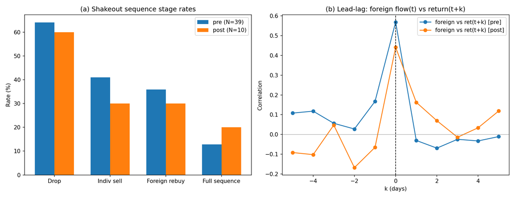

그림 2. (a) 시퀀스 단계별 충족률 전/후 비교 (b) 리드-래그 상관: 취임 전(청)은 k=+1에서 0 부근, 취임 후(주황)는 +0.16으로 유의한 선행성 출현.

## 5. 이벤트 스터디: 대량매도 이후 한 달

| 지표 (사후 21거래일) | 취임 전 (N=40) | 취임 후 (N=14) |
| --- | --- | --- |
| 대량매도 임계치 (하위 10%) | -0.46조 원 | -2.46조 원 (5.4배) |
| 사후 외인 누적수급 (건당 평균) | -2.12조 (p=0.003) | -23.74조 (p=0.0003) |
| 21일 내 순매수 전환 비율 | 28% (11/40) | 7% (1/14) |
| 사후 누적수익률(CAR) | +0.56% (p=0.47, 무반응) | +7.79% (p=0.02, 상승 지속) |

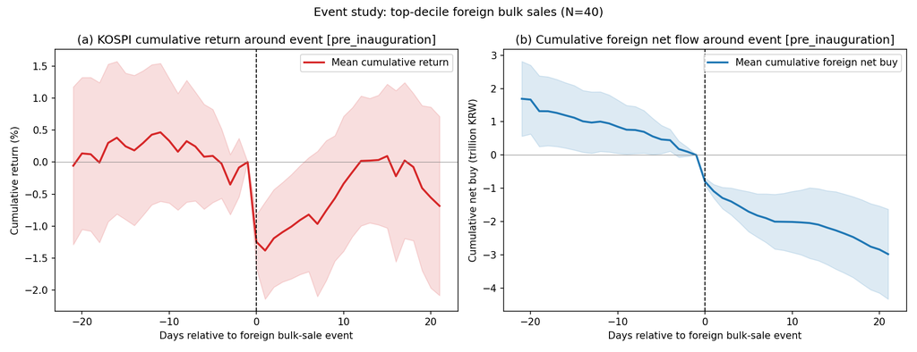

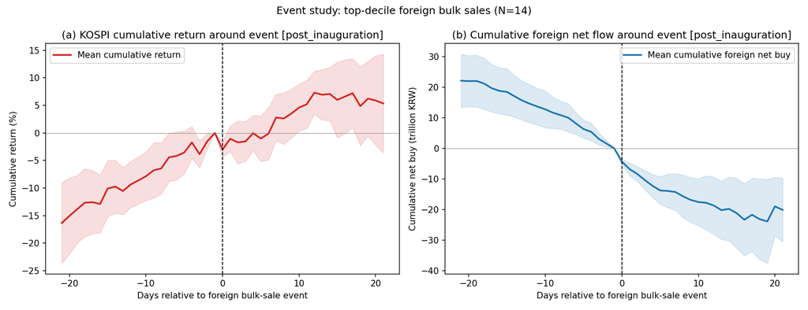

## 6. 리드-래그 상관: 선행성의 ‘출현’

| 상관계수 | 취임 전 | 취임 후 |
| --- | --- | --- |
| corr(외인<sub>t</sub>, 수익률<sub>t+1</sub>) — 익일 예측력 | -0.030 (t=-0.73, 무상관) | +0.163 (t=2.57, p≈0.01) |
| corr(외인<sub>t</sub>, 수익률<sub>t</sub>) — 동일시점 | +0.569 | +0.439 |
| corr(외인<sub>t</sub>, 개인<sub>t</sub>) — 거래상대방 | -0.742 | -0.867 |

취임 전 외국인 수급은 다음날 수익률에 대한 예측력이 전혀 없었다. **단기 선행성(정보 우위)은 취임 후 레짐에서 새로 생겼다** — 가설의 “취임 후 상관성 소멸” 예상과 정반대 방향이다. 외인-개인 상관 ≈ -0.8은 시장 청산 항등식에 따른 기계적 미러이므로 인과 해석은 금물.

## 7. 종합 결론

**데이터가 지지하는 서사는 “조작 사이클의 소멸”이 아니라 “행위자 성격의 전환”이다.**

취임 전(박스권 2.5년)의 외국인은 순포지션을 중립으로 유지하며 예측력 없는 **양방향 단기 트레이딩**을 했다. 취임 후 급등장에서는 **단기 가격 선행성을 보이며 1년간 109조 원을 일관되게 순매도하는 분배(distribution) 주체**로 변했고, 그 물량을 개인(+47조)과 기관(+45조)이 받아 지수가 +195% 상승했다.

공개 분석·논문에서 방어 가능한 명제: **“정권 교체 후 레짐에서 외국인 순매도의 단기 가격 선행성이 새로 출현했으며, 셰이크아웃(조작)형 사이클은 두 레짐 모두에서 부재한다.”**

## 8. 한계

**식별 문제:** 취임 전/후 구분은 동시에 박스권/급등장 구분이기도 하다 — 정권 효과와 시장 국면 효과를 이 데이터만으로 분리할 수 없다.  
**소표본:** 취임 후 이벤트 N=14(시퀀스 N=10). “패턴 없음”은 약한 패턴을 놓쳤을 가능성을 포함한다.  
**집계 수준:** 지수 수준 데이터로 종목 수준 순환매·재매수는 식별 불가.  
**임계치 정의:** 대량매도를 기간별 분위수로 정의해 두 시기의 절대 규모가 다름(의도된 설계).